# Gapminder dataset - understanding the indicators of growth among countries/regions

- Introduction
- Data Wrangling
- Exploratory Data Analysis
- Conclusions

## Introduction

Gapminder has collected a lot of information about how people live their lives in different countries, tracked across the years, and on various indicators, particular on living standards and economic development.

The data provided comes under Excel spreadsheet files, to which I plan to export each table as a CSV file. As of `27/06/19`, the data downloaded from the **[Gapminder database](https://www.gapminder.org/data/)** were the latest produced in the 'list of indicators in Gapminder tools (data currently used)'.

Given that I have to query these tables altogether across countries, I need to make sure the dataset is tidy via the process of data merging, manipulation and reshaping (data wrangling/cleaning) process before I can continue with the exploratory data analysis (EDA) phase. The columns should look something like this:

| Country | Year | Indicator 1 | indicator 2 | indicator 3 | indicator 4 |
| --- | --- | --- | --- | --- | --- |

The questions I intend on exploring throughout the report revolve around:

1. Have certain regions of the world been growing better than others?
2. Are there trends that can be observed between the selected metrics?

My case studies focus on *Brazil, China and India* as part of the `BRIC economies`, a club of emerging economies experiencing rapid growth over the last few decades, dissecting metrics to understand the gains in economic development. Moreover, the **dependent variable** I have chosen is:

- GDP/income per capita (income pc), which is a measure of living standards.

I have picked **three independent variables**:

- Life expectancy
- Exports (% of GDP)
- Investment rates (% of GDP)

I aim to find some links between an increase in any of these independent variables being linked with a corresponding increase in income pc.

```python
#import relevant packages for data analysis

import numpy as np
import pandas as pd
import matplotlib.pyplot as plt
import seaborn as sns
%matplotlib inline
```

## Data Wrangling

> **Tip**: In this section of the report, you will load in the data, check for cleanliness, and then trim and clean your dataset for analysis. Make sure that you document your steps carefully and justify your cleaning decisions.

### General Properties

```python
# Load your data and print out a few lines. Perform operations to inspect data
#   types and look for instances of missing or possibly errant data.

df_income = pd.read_csv('income_per_person_gdppercapita_ppp_inflation_adjusted.csv')
df_export = pd.read_csv('exports_percent_of_gdp (1).csv')
df_inv = pd.read_csv('investments_percent_of_gdp.csv')
df_life = pd.read_csv('life_expectancy_years.csv')
```

Given the various indicators/observations available across countries, it's important to notice the common years altogether for each indicator for when the datasets will be merged at the data cleaning stage.

```python
#first datset runs from 1800 to 2040
df_income.head(1)
```

|  | country | 1800 | 1801 | 1802 | 1803 | 1804 | 1805 | 1806 | 1807 | 1808 | ... | 2031 | 2032 | 2033 | 2034 | 2035 | 2036 | 2037 | 2038 | 2039 | 2040 |
| --- | --- | --- | --- | --- | --- | --- | --- | --- | --- | --- | --- | --- | --- | --- | --- | --- | --- | --- | --- | --- | --- |
| 0 | Afghanistan | 603 | 603 | 603 | 603 | 603 | 603 | 603 | 603 | 603 | ... | 2420 | 2470 | 2520 | 2580 | 2640 | 2700 | 2760 | 2820 | 2880 | 2940 |

1 rows × 242 columns

```python
#second dataset runs from 1800 to 2018
df_life.head(1)
```

|  | country | 1800 | 1801 | 1802 | 1803 | 1804 | 1805 | 1806 | 1807 | 1808 | ... | 2009 | 2010 | 2011 | 2012 | 2013 | 2014 | 2015 | 2016 | 2017 | 2018 |
| --- | --- | --- | --- | --- | --- | --- | --- | --- | --- | --- | --- | --- | --- | --- | --- | --- | --- | --- | --- | --- | --- |
| 0 | Afghanistan | 28.2 | 28.2 | 28.2 | 28.2 | 28.2 | 28.2 | 28.1 | 28.1 | 28.1 | ... | 55.7 | 56.2 | 56.7 | 57.2 | 57.7 | 57.8 | 57.9 | 58.0 | 58.4 | 58.7 |

1 rows × 220 columns

```python
# last 2 datsets runs from 1960 to 2017
df_export.head(1)
```

|  | country | 1960 | 1961 | 1962 | 1963 | 1964 | 1965 | 1966 | 1967 | 1968 | ... | 2008 | 2009 | 2010 | 2011 | 2012 | 2013 | 2014 | 2015 | 2016 | 2017 |
| --- | --- | --- | --- | --- | --- | --- | --- | --- | --- | --- | --- | --- | --- | --- | --- | --- | --- | --- | --- | --- | --- |
| 0 | Afghanistan | 4.13 | 4.45 | 4.88 | 9.17 | 8.89 | 11.3 | 8.57 | 6.77 | 8.9 | ... | 18.0 | 14.7 | 10.0 | 6.11 | 5.52 | 6.31 | 6.57 | 7.0 | 6.9 | NaN |

1 rows × 59 columns

```python
df_inv.head(1)
```

|  | country | 1960 | 1961 | 1962 | 1963 | 1964 | 1965 | 1966 | 1967 | 1968 | ... | 2008 | 2009 | 2010 | 2011 | 2012 | 2013 | 2014 | 2015 | 2016 | 2017 |
| --- | --- | --- | --- | --- | --- | --- | --- | --- | --- | --- | --- | --- | --- | --- | --- | --- | --- | --- | --- | --- | --- |
| 0 | Afghanistan | 16.1 | 16.6 | 19.1 | 14.2 | 13.9 | 11.3 | 8.41 | 5.18 | 6.47 | ... | 18.9 | 17.9 | 17.9 | 16.6 | 16.8 | 17.2 | 18.1 | 19.4 | 17.7 | NaN |

1 rows × 59 columns

```python
#detecting any overlap/match between variable across datasets/years

df_income.shape, df_export.shape, df_inv.shape, df_life.shape
```

```
((193, 242), (185, 59), (177, 59), (187, 220))
```

Hence, it is clear now that once further data cleaning is done, a combinded dataset of these variables will run from a sample of years between 1960-2017 (columns).

The data also needs to be in a **`long (panel/longitudinal) format`** to perform deeper analysis, querying and comparisons across countries that facilitates the EDA process.

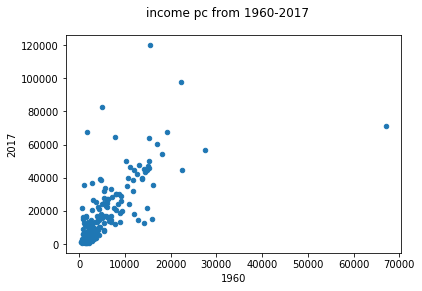

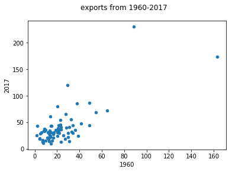

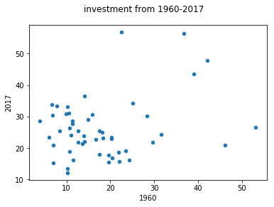

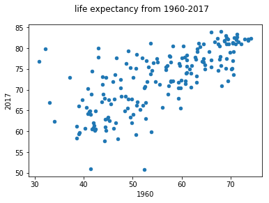

```python
# visualising any outliers/variability - years 1960-2017 for all variables

df_income.plot(kind='scatter', x='1960', y='2017', subplots=True, title= 'income pc from 1960-2017')
df_export.plot(kind='scatter', x='1960', y='2017', subplots=True, title= 'exports from 1960-2017')
df_inv.plot(kind='scatter', x='1960', y='2017', subplots=True, title= 'investment from 1960-2017')
df_life.plot(kind='scatter', x='1960', y='2017', subplots=True, title='life expectancy from 1960-2017')

# illustrate
plt.show()
```

We can roughly see among these variables that there is variability, indicating among the data points that there is growth in these indicators between 1960-2017 rather than a constant (unchanged) pattern that would otherwise indicate a lack of accessbility of data for some countries/indicators.

Albeit outliers remain somewhat for exports, investment and income_pc variables.

Given such diagnosis and insights, it becomes easier to fix any errors to perform data analysis and communication.

### Data Cleaning - gapminder dataset

Start by renaming the column labels

```python
#renaming country column to income per capita - 'income_pc'
df_income.rename(columns={'country': 'income_pc'}, inplace=True)

#renaming country column to export - 'export'
df_export.rename(columns={'country': 'export'}, inplace=True)

#renaming country column to investment - 'investment'
df_inv.rename(columns={'country': 'investment'}, inplace=True)

#renaming country column to life expectancy - 'life_exp'
df_life.rename(columns={'country': 'life_exp'}, inplace=True)
```

Utilise a function to check and drop missing/negative values

```python
def check_null_or_valid(row_data):
    """Function that takes a row of data,
    drops all missing values,
    and checks if all remaining values are greater than or equal to 0
    """
    no_na = row_data.dropna()
    numeric = pd.to_numeric(no_na)
    ge0 = numeric >= 0
    return ge0
```

```python
# Check whether the first column is 'income_pc'
assert df_income.columns[0] == 'income_pc'
```

```python
# check whether the first column is 'export'
assert df_export.columns[0] == 'export'
```

```python
# check whether the first column is 'life exp'
assert df_life.columns[0] == 'life_exp'
```

```python
# check whether the first column is 'investment'
assert df_inv.columns[0] == 'investment'
```

Check whether the values in the rows are valid for each variable dataframe.

```python
assert df_income.iloc[:, 1:].apply(check_null_or_valid, axis=1).all().all()
```

```python
assert df_export.iloc[:, 1:].apply(check_null_or_valid, axis=1).all().all()
```

```python
assert df_life.iloc[:, 1:].apply(check_null_or_valid, axis=1).all().all()
```

```python
try:
    assert df_inv.iloc[:, 1:].apply(check_null_or_valid, axis=1).all().all()
except AssertionError:
    print ('needs manual cleaning')
```

```
needs manual cleaning
```

Picking up an error in the investment variable signals that we have to fix this manually.

```python
# drop missing values along the rows
df_inv.dropna(axis=0, inplace=True)
```

```python
# checking zero non-null values for investment
df_inv.isnull().sum().sum()
```

```
0
```

```python
# confirming df_inv has zero null values
assert pd.notnull(df_inv.all)
```

```python
# Check that there is only one instance of each country
assert df_income['income_pc'].value_counts()[0] == 1
assert df_export['export'].value_counts()[0] == 1
assert df_inv['investment'].value_counts()[0] == 1
assert df_life['life_exp'].value_counts()[0] == 1
```

I am going to use `pd.melt()` to convert (reshape) the data from a wide to long format, where there is one column each for year and variable observations, keeping the dependent/independent variables (country labels for now) fixed.

```python
'''Reshape columns: income_pc, export,
investment and life_exp by melting it.
Keep reshaped columns fixed - specifying
as an argument to the id_vars parameter'''

# Melt income_pc: df1
df1 = pd.melt(df_income, id_vars= 'income_pc')

#Melt export: df2
df2 = pd.melt(df_export, id_vars= 'export')

#Melt investment: df3
df3 = pd.melt(df_inv, id_vars= 'investment')

#Melt life_exp: df4
df4 = pd.melt(df_life, id_vars= 'life_exp')
```

Quickly check how the dataframe manipulation looks like

```python
df1.head(1)
```

|  | income_pc | variable | value |
| --- | --- | --- | --- |
| 0 | Afghanistan | 1800 | 603 |

```python
df2.head(1)
```

|  | export | variable | value |
| --- | --- | --- | --- |
| 0 | Afghanistan | 1960 | 4.13 |

```python
df3.head(1)
```

|  | investment | variable | value |
| --- | --- | --- | --- |
| 0 | Algeria | 1960 | 42.2 |

```python
df4.head(1)
```

|  | life_exp | variable | value |
| --- | --- | --- | --- |
| 0 | Afghanistan | 1800 | 28.2 |

Rename the columns to its relevant/corresponding labels

```python
#rename the columns
df1.columns = ['country', 'year', 'income_pc']
df2.columns = ['country', 'year', 'export']
df3.columns = ['country', 'year', 'investment']
df4.columns = ['country', 'year', 'life_exp']
```

```python
df1.head(1)
```

|  | country | year | income_pc |
| --- | --- | --- | --- |
| 0 | Afghanistan | 1800 | 603 |

```python
df2.head(1)
```

|  | country | year | export |
| --- | --- | --- | --- |
| 0 | Afghanistan | 1960 | 4.13 |

```python
df3.head(1)
```

|  | country | year | investment |
| --- | --- | --- | --- |
| 0 | Algeria | 1960 | 42.2 |

```python
df4.head(1)
```

|  | country | year | life_exp |
| --- | --- | --- | --- |
| 0 | Afghanistan | 1800 | 28.2 |

confirm the datatypes for each melted dataframe

```python
df1.dtypes, df2.dtypes, df3.dtypes, df4.dtypes
```

```
(country      object
 year         object
 income_pc     int64
 dtype: object, country     object
 year        object
 export     float64
 dtype: object, country        object
 year           object
 investment    float64
 dtype: object, country      object
 year         object
 life_exp    float64
 dtype: object)
```

Now, before we merge each dataframe, we need to check that we have the necessary dtypes

The **year** column label for each of these dataframes should be in a numeric format rather than a string.

```python
# convert the year column for all dataframes to numeric

df1['year'] = pd.to_numeric(df1['year'])
df2['year'] = pd.to_numeric(df2['year'])
df3['year'] = pd.to_numeric(df3['year'])
df4['year'] = pd.to_numeric(df4['year'])
```

```python
# check the dtypes

# Test if country is of type object
assert df1.country.dtypes == np.object
assert df2.country.dtypes == np.object
assert df3.country.dtypes == np.object
assert df4.country.dtypes == np.object
```

```python
# Test if year is of type int64
assert df1.year.dtypes == np.int64
assert df2.year.dtypes == np.int64
assert df3.year.dtypes == np.int64
assert df4.year.dtypes == np.int64
```

```python
# Test variable columns for numeric types - np.int64 or np.float64
assert df1.income_pc.dtypes == np.int64
assert df2.export.dtypes == np.float64
assert df3.investment.dtypes == np.float64
assert df4.life_exp.dtypes == np.float64
```

The dataframes can all be merged together via `pd.merge()`

This will typically involve - `left_on=['c1','c2'], right_on = ['c1','c2'])`

```python
new_df1 = pd.merge(df1, df4, how='inner', left_on=['year','country'], right_on=['year','country'])
new_df2 = pd.merge(df2, df3, how='inner', left_on=['year','country'], right_on=['year','country'])

gapminder_df = pd.merge(new_df1, new_df2, how='inner', left_on=['year','country'], right_on=['year','country'])
gapminder_df.head()
```

|  | country | year | income_pc | life_exp | export | investment |
| --- | --- | --- | --- | --- | --- | --- |
| 0 | Algeria | 1960 | 6520 | 52.0 | 39.00 | 42.20 |
| 1 | Argentina | 1960 | 9030 | 64.1 | 7.60 | 23.50 |
| 2 | Australia | 1960 | 14300 | 71.3 | 13.00 | 31.60 |
| 3 | Bangladesh | 1960 | 1060 | 43.8 | 10.00 | 6.89 |
| 4 | Benin | 1960 | 1190 | 41.1 | 6.12 | 11.40 |

```python
# check the gapminder_df,shape
gapminder_df.shape
```

```
(2784, 6)
```

Last stages of the data cleaning process

```python
# Check if there are any missing data,
#if yes drop the rows containing missing data
def check_and_drop(df):
    if pd.isna(df).sum().sum():
        return df.dropna(axis=0)
    return df
```

```python
gapminder = check_and_drop(gapminder_df)
```

```python
#outcome
gapminder.isnull().sum().sum()
```

```
0
```

```python
#overcoming ealier attempts of getting rid of negative/0 values in the investment column
gapminder_clean = gapminder.query('investment > 0')
```

```python
def check_null_or_valid(row_data):
    """Function that takes a row of data,
    drops all missing values,
    and checks if all remaining values are greater than or equal to 0
    """
    no_na = row_data.dropna()
    numeric = pd.to_numeric(no_na)
    ge0 = numeric >= 0
    return ge0
```

Apply the function again

```python
#final check of dataset cleaning: gapminder_clean
assert gapminder_clean.iloc[:, 1:].apply(check_null_or_valid, axis=1).all().all()
```

```python
gapminder_clean.dtypes
```

```
country        object
year            int64
income_pc       int64
life_exp      float64
export        float64
investment    float64
dtype: object
```

```python
gapminder_clean.shape
```

```
(2760, 6)
```

save all these changes to one new csv file `'gapminder_edited.csv'`

```python
gapminder_clean.to_csv('gapminder_edited.csv', index=False)
```

## Exploratory Data Analysis (EDA)

```python
# Load clean dataset
gapminder = pd.read_csv('gapminder_edited.csv')
gapminder.head()
```

|  | country | year | income_pc | life_exp | export | investment |
| --- | --- | --- | --- | --- | --- | --- |
| 0 | Algeria | 1960 | 6520 | 52.0 | 39.00 | 42.20 |
| 1 | Argentina | 1960 | 9030 | 64.1 | 7.60 | 23.50 |
| 2 | Australia | 1960 | 14300 | 71.3 | 13.00 | 31.60 |
| 3 | Bangladesh | 1960 | 1060 | 43.8 | 10.00 | 6.89 |
| 4 | Benin | 1960 | 1190 | 41.1 | 6.12 | 11.40 |

Making queries to filter for selected regions via `'country' == [name]'` - each assigned to a corresponding dataframe

```python
gapminder_brazil = gapminder.query('country == "Brazil"')
gapminder_china = gapminder.query('country == "China"')
gapminder_india = gapminder.query('country == "India"')
```

### Q1 Have certain regions of the world been growing in terms of income per capita better than others? - cases of Brazil, China and India

```python
#Brazil summary statistics 1960-2017
gapminder_brazil.describe().iloc[:,1:]
```

|  | income_pc | life_exp | export | investment |
| --- | --- | --- | --- | --- |
| count | 58.000000 | 58.000000 | 58.000000 | 58.000000 |
| mean | 10126.206897 | 67.567241 | 9.596034 | 20.124138 |
| std | 3179.475201 | 5.482392 | 2.843636 | 2.625737 |
| min | 4440.000000 | 56.800000 | 3.870000 | 15.400000 |
| 25% | 8430.000000 | 63.300000 | 7.152500 | 17.975000 |
| 50% | 10650.000000 | 68.200000 | 9.045000 | 19.850000 |
| 75% | 11575.000000 | 72.325000 | 11.575000 | 21.800000 |
| max | 15400.000000 | 75.500000 | 16.500000 | 26.900000 |

```python
#china summary statistics 1960-2017
gapminder_china.describe().iloc[:,1:]
```

|  | income_pc | life_exp | export | investment |
| --- | --- | --- | --- | --- |
| count | 58.000000 | 58.000000 | 58.000000 | 58.000000 |
| mean | 3650.327586 | 65.331034 | 14.118276 | 36.413793 |
| std | 4061.833418 | 9.366143 | 9.889812 | 7.218846 |
| min | 560.000000 | 30.900000 | 2.490000 | 15.300000 |
| 25% | 896.500000 | 62.850000 | 4.360000 | 33.100000 |
| 50% | 1610.000000 | 66.700000 | 13.050000 | 36.750000 |
| 75% | 4620.000000 | 71.150000 | 20.750000 | 40.900000 |
| max | 15200.000000 | 76.800000 | 36.000000 | 47.700000 |

```python
#china summary statistics 1960-2017
gapminder_india.describe().iloc[:,1:]
```

|  | income_pc | life_exp | export | investment |
| --- | --- | --- | --- | --- |
| count | 58.000000 | 58.000000 | 58.000000 | 58.000000 |
| mean | 2265.689655 | 57.143103 | 10.545517 | 25.577586 |
| std | 1474.137407 | 7.750837 | 7.006385 | 7.813125 |
| min | 1030.000000 | 41.500000 | 3.340000 | 14.600000 |
| 25% | 1167.500000 | 51.125000 | 4.972500 | 19.325000 |
| 50% | 1665.000000 | 58.350000 | 6.955000 | 24.550000 |
| 75% | 2740.000000 | 63.400000 | 14.925000 | 29.850000 |
| max | 6480.000000 | 68.900000 | 25.400000 | 42.500000 |

```python
# using vectorised operations to compute the income_pc growth rates (percentage changes) for each country.

china_pc_growth = gapminder_china['income_pc_growth'] = gapminder_china.groupby('country')['income_pc'].pct_change() * 100
india_pc_growth = gapminder_india['income_pc_growth'] = gapminder_india.groupby('country')['income_pc'].pct_change() * 100
brazil_pc_growth = gapminder_brazil['income_pc_growth'] = gapminder_brazil.groupby('country')['income_pc'].pct_change() * 100
```

> Plotting a bar chart to see who had the fastest income per capita growth rates on average between (1960-2017)

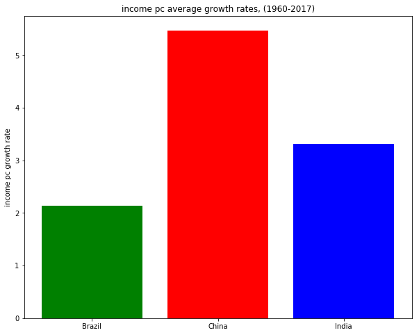

```python
growth_rates = china_pc_growth.mean(), india_pc_growth.mean(), brazil_pc_growth.mean()
countries = ['China', 'India', 'Brazil'] # x-axis labels

plt.rcParams['figure.figsize'] = 10,8 #default fig size
plt.bar(x= countries, height= growth_rates, color=['r','b','g']) #color for each country
plt.ylabel('income pc growth rate')
plt.title('income pc average growth rates, (1960-2017)')
plt.show()
```

```python
print("China's income pc growth rate between 1960-2017 was {}".format(china_pc_growth.mean()))
print("India's income pc growth rate between 1960-2017 was {}".format(india_pc_growth.mean()))
print("Brazil's income pc growth rate between 1960-2017 was {}".format(brazil_pc_growth.mean()))
```

```
China's income pc growth rate between 1960-2017 was 5.47405107412519
India's income pc growth rate between 1960-2017 was 3.31820744163368
Brazil's income pc growth rate between 1960-2017 was 2.135598672107886
```

- China accumulated the highest income per capita growth rates between 1960-2017, at around 5.5% per year on average
- India and Brazil followed, incurring respectable income per capita growth rates at around 3.3% and 2.1% per year on average over the same period.

> Illustrating line plots to see the overall income per capita growth trend for each country between 1960-2017, pointing out how much each countries' income per capita grew first from 1960, then its level by 2017

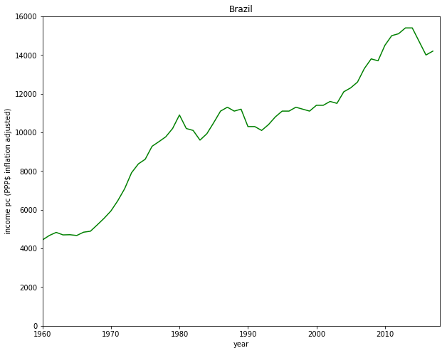

```python
gapminder_brazil.plot(x='year', y='income_pc', kind='line', legend=False, xlim=(1960,2018), ylim=(0,16000), title='Brazil', color='g')
plt.rcParams['figure.figsize'] = 12,8
plt.ylabel('income pc (PPP$ inflation adjusted)')
plt.show()
```

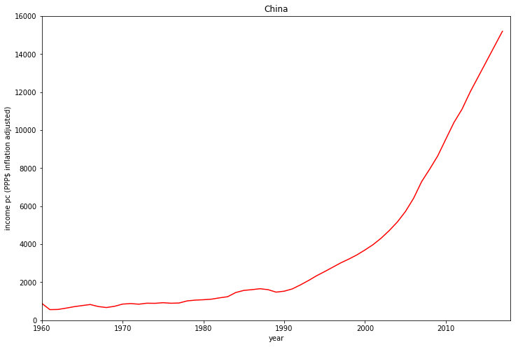

```python
gapminder_china.plot(x='year', y='income_pc', kind='line', legend=False, xlim=(1960,2018), ylim=(0,16000), title='China', color='r')
plt.rcParams['figure.figsize'] = 12,8
plt.ylabel('income pc (PPP$ inflation adjusted)')
plt.show()
```

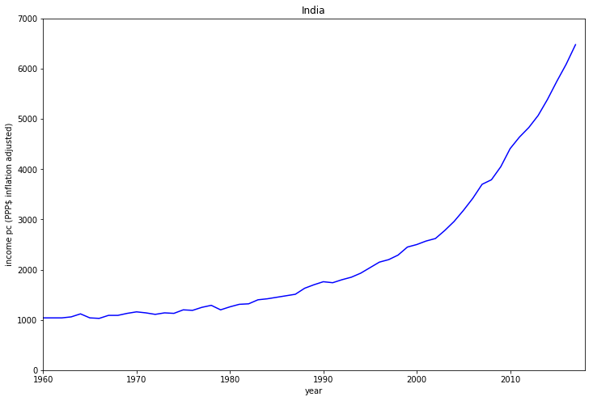

```python
gapminder_india.plot(x='year', y='income_pc', kind='line', legend=False, xlim=(1960,2018), ylim=(0,7000), title='India', color='b')
plt.rcParams['figure.figsize'] = 12,8
plt.ylabel('income pc (PPP$ inflation adjusted)')
plt.show()
```

```python
print("China's income per capita was ${} in 1960, it grew to ${} by 2017 ".format(gapminder_china.head(1).iloc[0,2], gapminder_china.tail(1).iloc[0,2]))
print("India's income per capita was ${} in 1960, it grew to ${} by 2017 ".format(gapminder_india.head(1).iloc[0,2], gapminder_india.tail(1).iloc[0,2]))
print("Brazil's income per capita was ${} in 1960, it grew to ${} by 2017 ".format(gapminder_brazil.head(1).iloc[0,2], gapminder_brazil.tail(1).iloc[0,2]))
```

```
China's income per capita was $891 in 1960, it grew to $15200 by 2017
India's income per capita was $1040 in 1960, it grew to $6480 by 2017
Brazil's income per capita was $4440 in 1960, it grew to $14200 by 2017
```

- China and India grow at exponential rates, particularly after the 1990s.
- Brazil by contrast incurred more periods of relative decline in their income per capita levels, particularly during the end of 1970s/start of the 1980s, indicating some sort of economic crisis that they became inflicted by. The mid 2010s also showed a similar trend.
- In 1960, China started the poorest out of the selected countries in terms of income per capita at $891$ with Brazil being the richest in terms of income per capita at $4440$.
- By 2017, China converged, becoming the richest out of the selected countries at an income per capita of $15200$, while Brazil slightly falling short with an income per capita of $14200$.
- Even though India started out slightly richer than China at $1040$ in 1960, its income per capita has grown to $6480$ by 2017, which is less than half of both Brazil and China's income per capita level.

> Illustrating histograms of each country to describe the distributon of income among the population

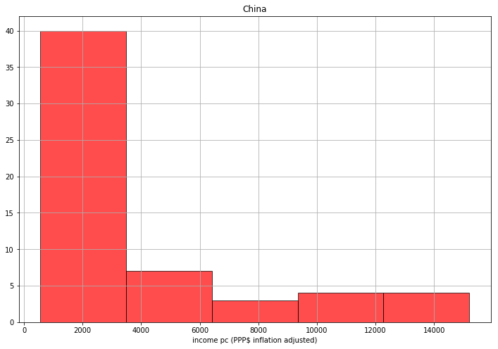

```python
gapminder_china['income_pc'].hist(color='r', alpha=0.7, edgecolor='black', bins=5)
plt.rcParams['figure.figsize'] = 6,8
plt.xlabel('income pc (PPP$ inflation adjusted)')
plt.title('China')
plt.show();
```

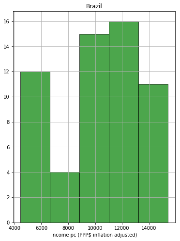

```python
gapminder_brazil['income_pc'].hist(color='g', alpha=0.7, edgecolor='black', bins=5)
plt.rcParams['figure.figsize'] = 6,8
plt.xlabel('income pc (PPP$ inflation adjusted)')
plt.title('Brazil')
plt.show();
```

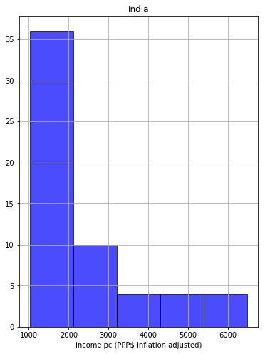

```python
gapminder_india['income_pc'].hist(color='b', alpha=0.7, edgecolor='black', bins=5 )
plt.rcParams['figure.figsize'] = 6,8
plt.xlabel('income pc (PPP$ inflation adjusted)')
plt.title('India')
plt.show();
```

> Using box plots to disect the distribution of income further - with regards to outliers and tails

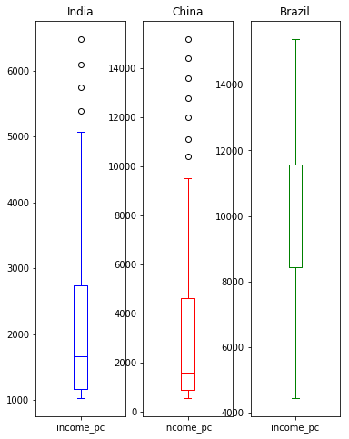

```python
#creating subplots - boxplots of each country to disect the distribution of income.
fig, (ax1,ax2,ax3) = plt.subplots(1,3)
plt.rcParams['figure.figsize'] = 16,12

gapminder_india['income_pc'].plot(kind='box', ax=ax1, title='India', color= 'b')
gapminder_china['income_pc'].plot(kind='box', ax=ax2, title='China', color= 'r')
gapminder_brazil['income_pc'].plot(kind='box', ax=ax3, title='Brazil', color = 'g')
```

```python
#calculating median incomes for sample countries
print("India's median income per capita is {}".format(gapminder_india.income_pc.median()))
print("China's median income per capita is {}".format(gapminder_china.income_pc.median()))
print("Brazil's median income per capita is {}".format(gapminder_brazil.income_pc.median()))
```

```
India's median income per capita is 1665.0
China's median income per capita is 1610.0
Brazil's median income per capita is 10650.0
```

### Q2 Are there trends that can be observed between the selected metrics? - cases of Brazil, China and India

> creating correlation heat maps and various scatter plots to discover trends between the selected metrics
> - dependent variable - income per capita
> - independent variables - life expectancy, exports (% of GDP) and investment (% of GDP).

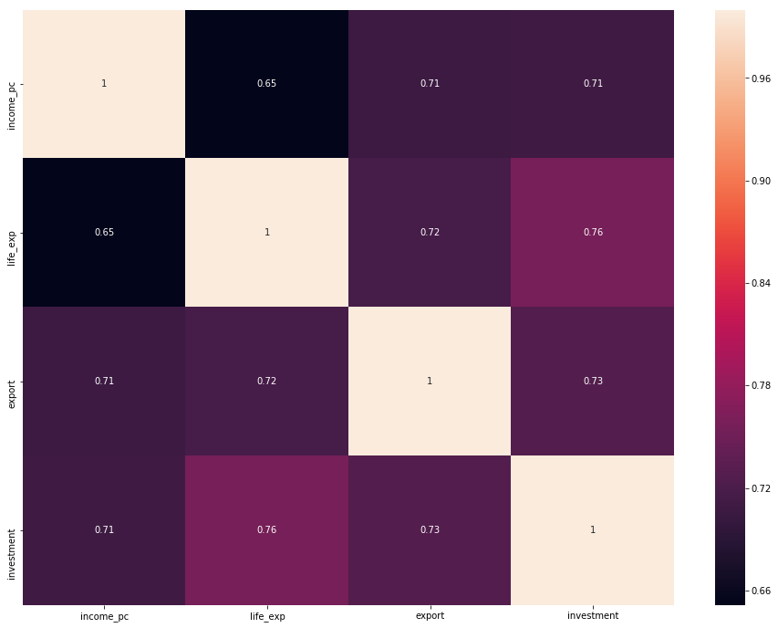

```python
# China relevant plots and trends

china_corr = gapminder_china.corr().iloc[1:5,1:5]

sns.heatmap(china_corr,
            xticklabels=china_corr.columns.values,
            yticklabels=china_corr.columns.values, annot=True)

plt.rcParams['figure.figsize'] = 8,8
```

###### correlation coefficients for China - between income pc and independent variables

- income pc and life expectancy - 0.65
- income pc and exports - 0.71
- income pc and investment - 0.71

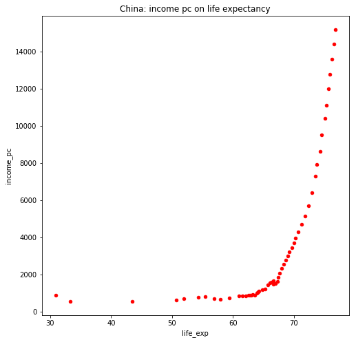

```python
# China scatter plots

gapminder_china.plot(kind='scatter', y='income_pc', x='life_exp', color='r', title='China: income pc on life expectancy')
plt.rcParams['figure.figsize'] = 12,8
```

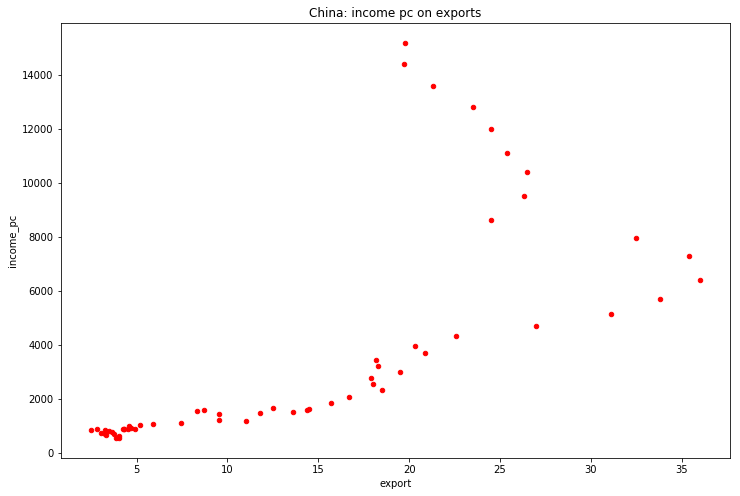

```python
gapminder_china.plot(kind='scatter', y='income_pc', x='export', color='r', title='China: income pc on exports')
plt.rcParams['figure.figsize'] = 12,8
```

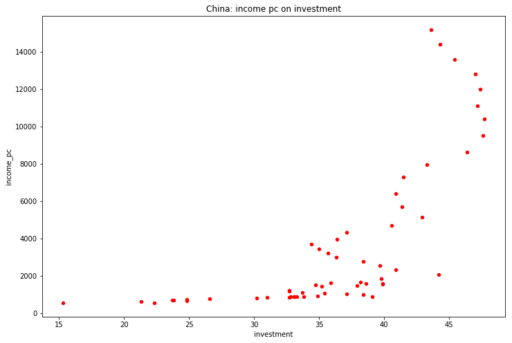

```python
gapminder_china.plot(kind='scatter', y='income_pc', x='investment', color='r', title='China: income pc on investment')
plt.rcParams['figure.figsize'] = 12,8
```

- In China, there is a positive correlation between income per capita and life expectancy ($0.65$), where the scatter plot shows an exponential correlation.
- Also there is a positive correlation between income per capita and exports/investment levels (both $0.71$), where the scatter plot shows an increasing trend, with most variability at the upper ends.

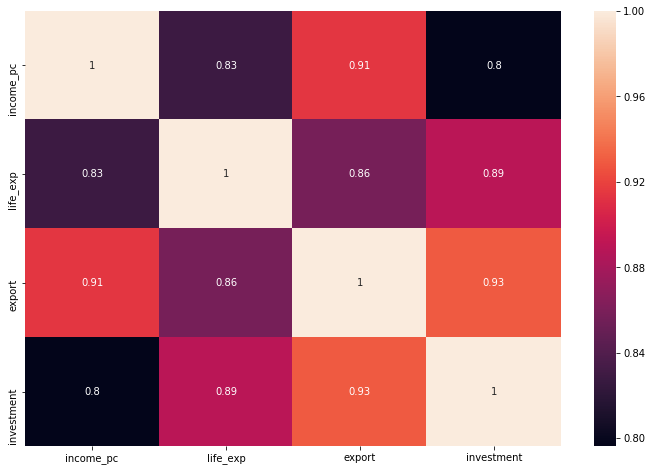

```python
india_corr = gapminder_india.corr().iloc[1:5,1:5]

sns.heatmap(india_corr,
            xticklabels=india_corr.columns.values,
            yticklabels=india_corr.columns.values, annot=True)
plt.rcParams['figure.figsize'] = 8,8
```

###### correlation coefficients for India - between income per capita and independent variables

- income pc and life expectancy - 0.83
- income pc and exports - 0.91
- income pc and investment - 0.8

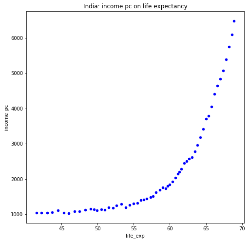

```python
# India scatter plots

gapminder_india.plot(kind='scatter', y='income_pc', x='life_exp', color='b', title='India: income pc on life expectancy')
plt.rcParams['figure.figsize'] = 12,8
```

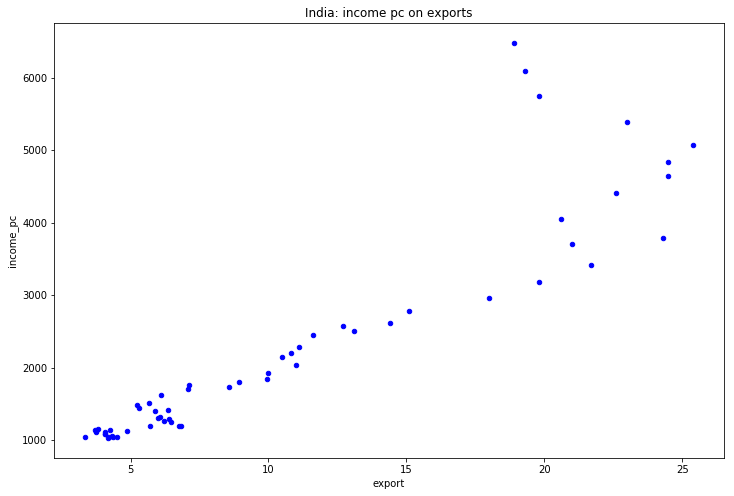

```python
gapminder_india.plot(kind='scatter', y='income_pc', x='export', color='b', title='India: income pc on exports')
plt.rcParams['figure.figsize'] = 12,8
```

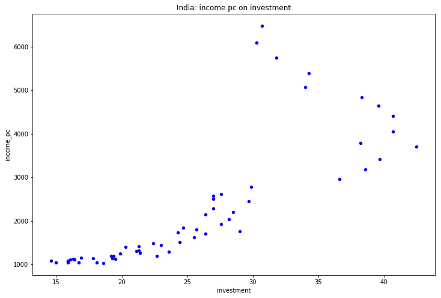

```python
gapminder_india.plot(kind='scatter', y='income_pc', x='investment', color='b', title='India: income pc on investment')
plt.rcParams['figure.figsize'] = 12,8
```

- In India, there is a relatively strong positive correlation between income per capita and life expectancy ($0.83$), where the scatter plot shows an exponential correlation.
- There is also a very strong positive correlation between income per capita and exports ($0.91$), where the scatter plot shows an increasing trend, with some variability at the upper ends.
- Finally, there is a relatively strong positive correlation between income per capita and investment ($0.8$), where the scatter plots shows an increasing trend, with some variability at the middle/upper ends.

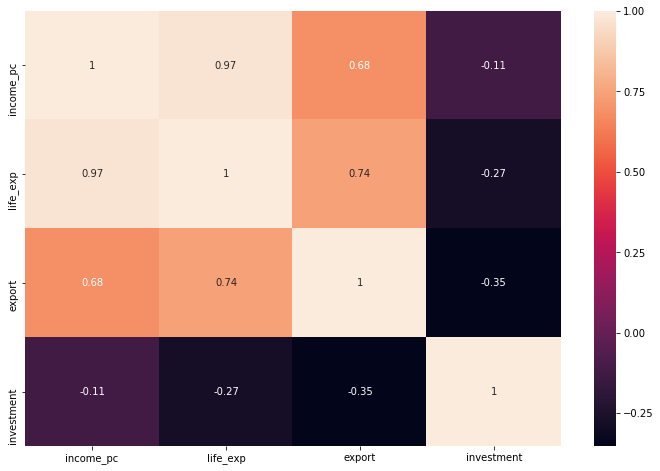

```python
brazil_corr = gapminder_brazil.corr().iloc[1:5,1:5]

sns.heatmap(brazil_corr,
            xticklabels=brazil_corr.columns.values,
            yticklabels=brazil_corr.columns.values, annot=True)
plt.rcParams['figure.figsize'] = 8,8
```

###### correlation coefficients for Brazil - between income per capita and independent variables

- income pc and life expectancy - 0.97
- income pc and exports - 0.68
- income pc and investment - -0.11

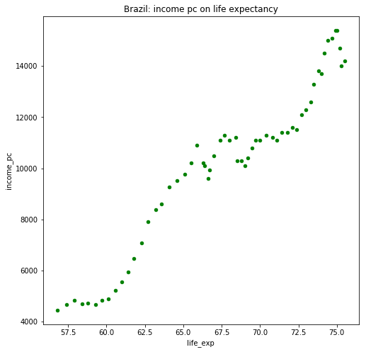

```python
# Brazil scatter plots

gapminder_brazil.plot(kind='scatter', y='income_pc', x='life_exp', color='g', title='Brazil: income pc on life expectancy')
plt.rcParams['figure.figsize'] = 12,8
```

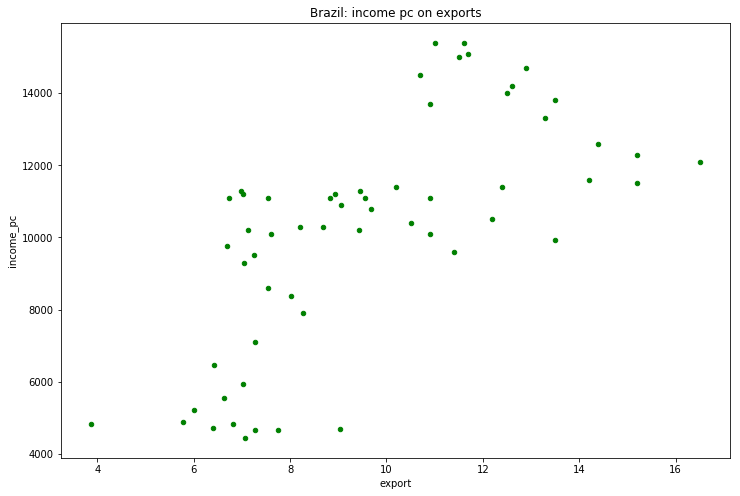

```python
gapminder_brazil.plot(kind='scatter', y='income_pc', x='export', color='g', title='Brazil: income pc on exports')
plt.rcParams['figure.figsize'] = 12,8
```

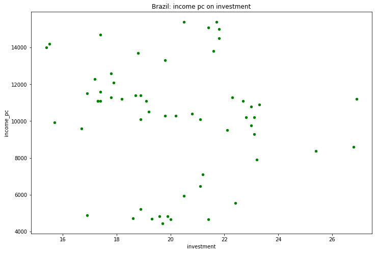

```python
gapminder_brazil.plot(kind='scatter', y='income_pc', x='investment', color='g', title='Brazil: income pc on investment')
plt.rcParams['figure.figsize'] = 12,8
```

- In Brazil, there is a very strong positive correlation between income per capita and life expectancy ($0.97$), where the scatter plot shows an almost perfect linear correlation.
- Moreover, there is a positive correlation between income per capita and exports ($0.68$), where the scatter plot shows an increasing trend, with variability in certain thresholds of the data points.
- In contrast to China and India, there is a negative (albeit very weak) correlation between income per capita and investment ($-0.11$), where the scatter shows an approximate decreasing trend, with a lot of variability throughout the data points.

## Conclusions

##### Summary of findings and results:

Out of sample BRIC countries, China grew at the fastest rate on average in terms of income pc (5.5%) between 1960-2017, compared to India (3.31%) and Brazil (2.1%).

China and India both grew at exponential rates, especially after the 1990s. Brazil also grew rapidly in phases, but incurred periods of decline via the turn of the 1980s and mid-2010s.

China started the poorest of the three countries in 1960 with an income pc of 891, while Brazil started as the richest with an income pc of 4440. However, China caught up to Brazil by 2017, rising to an income pc of 15200, with Brazil slightly lower at an income pc of 14200.

- Income pc on life expectancy - shows a positive correlation for each country, being strongest for Brazil (0.97), being relatively stronger for India (0.83) and relatively weaker for China (0.65).
- Income pc on exports - shows a positive correlation for each country, being strongest for India (0.91) and weakest for Brazil (0.68), while being slightly higher in China (0.71).
- Income pc on investment - only shows a positive correlation for China and India, reported to be 0.71 and 0.8 respectively. In Brazil's case, there is a negative (very weak) correlation between income pc and investment rates at -0.11.

##### Limitations and implications

Given such notes on trend across these sample countries in economic development, there are caveats to making firm conclusions.

A *correlation* only illustrates the presence/absence of a relationship; **this does not imply causation**. The possibility of measurement errors like a relevant variable being omitted can cause bias and influence the results. This makes sense when trying judge a negative/no correlation in Brazil for income pc on investment despite there being a positive correlation for those same variables in China and India, as there is a possibility of some variable/details missing. Hence, there needs to be statistical testing to make such conclusions, which is beyond the scope of this analysis.

Only three countries were used, which is not entirely representative of indicators of global economic development across countries. An improvement could be to include other economies in other regions such as Africa and Europe.

Also, a longer time frame before 1960 may be of use in determining longer term trends of growth. This is perhaps only possible when picking indicators that are widely available/recorded across regions including, emerging economies. Hence, exports and investment should be replaced by other economic indicators to achieve such a result.

## Submitting your Project

> Before you submit your project, you need to create a .html or .pdf version of this notebook in the workspace here. To do that, run the code cell below. If it worked correctly, you should get a return code of 0, and you should see the generated .html file in the workspace directory (click on the orange Jupyter icon in the upper left).

> Alternatively, you can download this report as .html via the **File** > **Download as** submenu, and then manually upload it into the workspace directory by clicking on the orange Jupyter icon in the upper left, then using the Upload button.

> Once you've done this, you can submit your project by clicking on the "Submit Project" button in the lower right here. This will create and submit a zip file with this .ipynb doc and the .html or .pdf version you created. Congratulations!

```python
from subprocess import call
call(['python', '-m', 'nbconvert', 'Investigate_a_Dataset.ipynb'])
```

```
255
```